# The Cash Counties of PA

Dominick Weakley

## Introduction

Wealth disparity has been a hotly debated issue in the United States for around for as long as I can remember. Politicians from both the left and right waste no time weighing in on the issue, offering the public thousands of theories to why this happened and how. I’ve grown extremely tired hearing all of the speeches and plans these politicians have. Thus, I have decided to take an in-depth statistical analysis of wealth disparity, investigating where wealth disparity is greatest and why. Statistics indicate that the top 10 wealthiest percent of population control 75 percent of the wealth and the lowest 70 percent the populist control only 6.9 percent of the wealth. I want to focus my attention on the potential social factors that affect wealth disparity. I chose to focus on the wealth disparity in the working class city of Pittsburgh, PA. More specifically I want to focus on the disparity of wealth in the seven different counties that make up the greater Pittsburgh. To calculate the wealth disparity I will be using the Gini coefficient. The Gini coefficient is a statistical formula that calculates the income or wealth distribution of an area’s residents and is commonly used to measure the inequality of wealth among residents. The closer the Gini coefficient is to 1 the greater the disparity.

## Analysis

When looking at the Mean Gini coefficient of each county, two counties stand out. As seen below both Fayette and Allegheny County serve as anomalies when comparing the mean Gini coefficient. Both counties show a much higher Gini coefficient as they are the only counties to have a Gini coefficient over .435. The next highest county, Washington, shows a Gini coefficient of only .416.

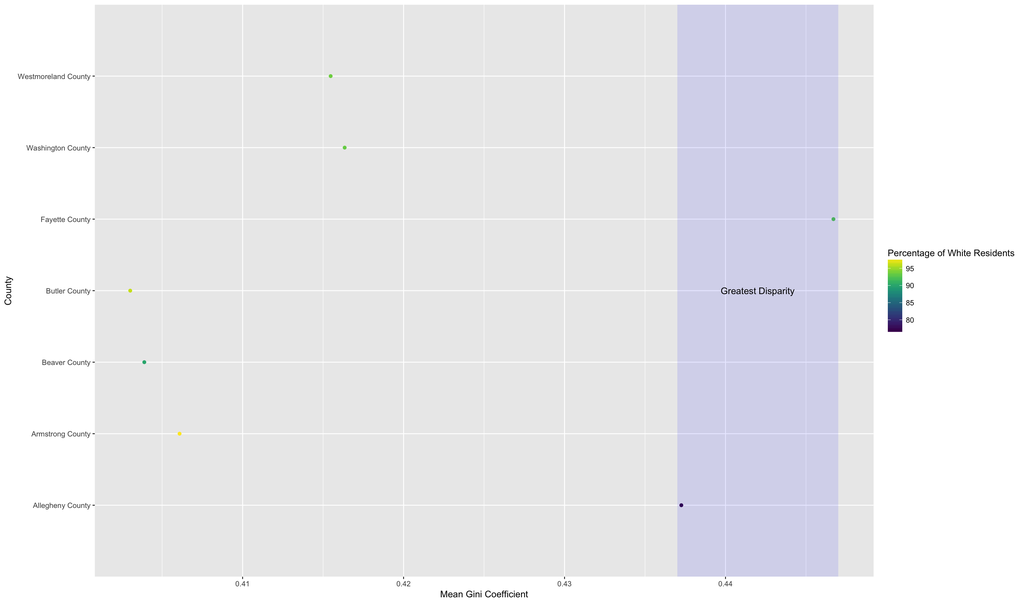

Since Fayette and Allegheny counties have the greatest wealth disparity in the greater Pittsburgh area, exploring the demographics of the two countries is vital to understanding the potential social factors that affect wealth disparity in the United States. The county of Fayette has the greatest mean disparity of any Pittsburgh county, but as the scale above indicates that may not have to do with racial demographics. With a reported 92.6% white population, Fayette County is a middle of the road county in terms of demographics. Fayette’s disparity in wealth most likely stems from other social factors we will explore below. Allegheny, on the other hand, is reported to be 76.5% white, the lowest percentage of any county by 13%. Since the difference in demographics is so extremely different for Allegheny county when compared to the other Pittsburgh counties I can logically conclude that in Allegheny county wealth disparity runs along racial lines.

Differences in racial demographics are not the only potential factor that affects the wealth disparity of a city or county. Different gender divides in among a population may also play an important role. Since the average female worker earns only 81.3% of what the average male makes the gender difference in a county could greatly affect the wealth distribution.

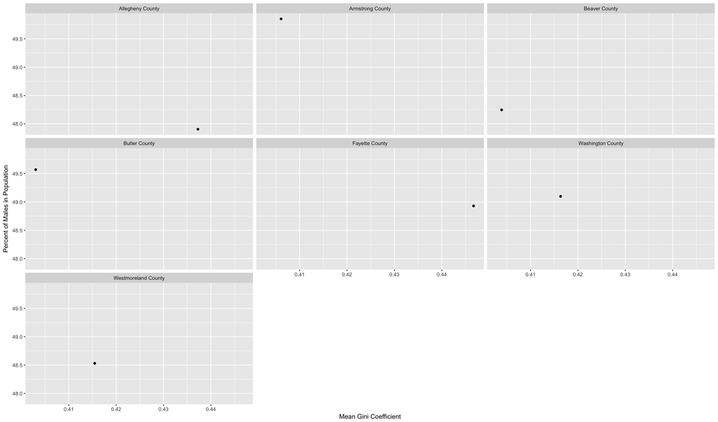

According to the graphs above, there is no direct relationship between the gender makeup of a county and the Gini coefficient. Similar to the results of the first graph and relationship, the wealth disparity of Fayette does not seem to caused by the social factor observed. Fayette was not an anomaly as I had expected, instead of turning out to be middle of the road again. In fact, Allegheny is the only county to that shows an impactful relationship between gender and its wealth disparity. There is not a relationship between gender and Gini coefficient in any of the other counties of greater Pittsburgh.

The final factor that I will be investigating that can affect wealth disparity is not directly linked to demographics but is based on location. Allegheny County is the most densely populated county in the data group, encompassing downtown Pittsburgh and most of its urban areas. The city of Pittsburgh shows a fiscally diverse populace expected of any city in the northeast. The fiscal numbers come from the income of residents during the first Quartile (Q1). Allegheny county containing urban Pittsburgh, directly affects its wealth disparity, due to the diversity of work available in urban cities.

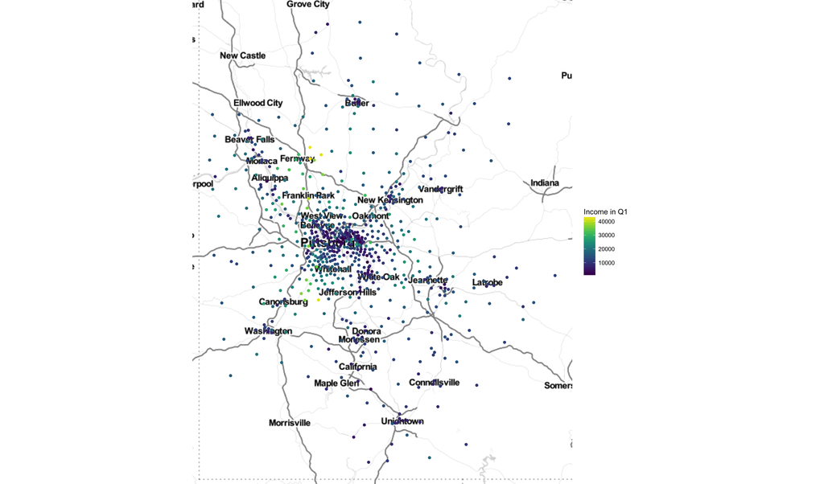

## References

All products require an annual contract. Prices do not include sales tax (New York residents only). “U.S. Wealth Distribution in 2017 | Statistic.” Statista, www.statista.com/statistics/203961/wealth-distribution-for-the-us/.

Doyle, Alison. “How Much Is the Average Salary for US Workers?” The Balance, www.thebalance.com/average-salary-information-for-us-workers-2060808.